# Diseños de medidas repetidas sin réplicas

Gerardo Martín

31/3/2021

# 1 Introducción

En la clase del diseño split-plot se mencionó que los diseños de medidas repetidas pueden se considerados estadísticamente análogos, pues los tratamientos están anidados en las unidades experimentales. La principal diferencia entre ambos diseños radica en que el anidamiento en los diseños split-plot es espacial, mientras que en los diseños de medidas repetidas el anidamiento es temporal. Las mediciones repetidas en las unidades experimentales pueden corresponder a la aplicación secuencial de tratamientos, o a la medición del efecto acumulado del mismo tratamiento. Debido a este componente temporal, los diseños de medidas repetidas tienden a durar más tiempo que otros diseños donde se aplican todos los tratamientos al mismo tiempo pero en unidades experimentales diferentes.

Como podemos ver, en los diseños de medidas repetidas hay una serie de trueques. Por un lado, estos diseños permiten que los experimentos se realicen con menos unidades experimentales, pero requieren de más tiempo. Existen además importantes consideraciones biológicas, pues en necesario que los tratamientos no tendrán un efecto sobre el comportamiento de la unidad experimental que ya recibió otro tratamiento.

Resulta evidente entonces que, como en todos los diseños experimentales, la decisión de hacer mediciones repetidas debe estar basada en en una serie de criterios:

1. **Logísticos** Se debe asegurar que habrá personal calificado para toda la duración del experimento
2. **Éticos** Se debe asegurar que la aplicación de trataientos subsecuentes no resultará en daño a los organismos experimentales (en caso de existir).

# 2 Análisis de diseños de medidas repetidas

El análisis de los diseños con medidas repetidas es igual al de los diseños split-plot, porque en esencia consiste de un ANOVA anidado. Por lo tanto, la mayor complicación del análisis es la identificación correcta de la estructura de anidación —¿qué tratamientos están contenidos dentro de cada unidad experimental?

Aquí haremos otro análisis anidado de un diseño de tres vías con medidas repetidas. La base analizada está contenida en `datarium` bajo el nombre `weightloss`.

## 2.1 `Weightloss`

Comenzaremos, nuevamente, cargando la base de datos, viendo en qué formato está y si es necesario transformarla.

```r
weight <- datarium::weightloss
knitr::kable(head(weight)) # Imprimiendo las primeras seis filas de weightloss
```

| id | diet | exercises | t1 | t2 | t3 |
| --- | --- | --- | --- | --- | --- |
| 1 | no | no | 10.43 | 13.21 | 11.59 |
| 2 | no | no | 11.59 | 10.66 | 13.21 |
| 3 | no | no | 11.35 | 11.12 | 11.35 |
| 4 | no | no | 11.12 | 9.50 | 11.12 |
| 5 | no | no | 9.50 | 9.73 | 12.28 |
| 6 | no | no | 9.50 | 12.74 | 10.43 |

Al igual que los otros diseños anidados que vimos (`slefesteem2`), está en formato ancho en el factor tiempo, por lo que hay que utilizar `reshape2::melt` para darle formato largo. Para que `melt` funcione como queremos (mantener una columna para cada factor experimental), necesitamos especificar qué columnas permanecerán así en el argumento `id.vars`:

```r
weight.l <- reshape2::melt(weight, id.vars = c("id", "diet", "exercises"))
names(weight.l) <- c("id", "diet", "exercises", "time", "loss")
knitr::kable(head(weight.l)) #Imprimiendo las primeras seis filas de la tabla resultante
```

| id | diet | exercises | time | loss |
| --- | --- | --- | --- | --- |
| 1 | no | no | t1 | 10.43 |
| 2 | no | no | t1 | 11.59 |
| 3 | no | no | t1 | 11.35 |
| 4 | no | no | t1 | 11.12 |
| 5 | no | no | t1 | 9.50 |
| 6 | no | no | t1 | 9.50 |

Al igual que `selfesteem2`, `weightloss` contiene tres mediciones de la pérdida de peso por cada tratamiento aplicado a los individuos. Los factores `diet` y `exercises` fueron aplicados simultáneamente, por lo que sólo `time` está anidado en ambos, lo cual constituye la principal diferencia con `selfesteem2` que sólo incluye dos factores anidados en los individuos. Con base en esta estructura experimental, podemos contemplar la existencia de interacciones entre `diet` y `exercises`. La interacción con tiempo debe existir porque está anidado en ambos factores.

Antes de continuar con el análisis hagamos una rápida verificación de la distribución de `loss`, esta vez, utilizando únicamente la pruebe de shapiro para cada grupo experimental:

```r
library(tidyverse); library(rstatix)
shap.test <- weight.l %>%
   group_by(diet, exercises, time) %>%
   shapiro_test(loss)
knitr::kable(shap.test, caption = "Resultados de la prueba de Shapiro dentro de cada grupo experimental.", align = "c")
```

Table 2.1: Resultados de la prueba de Shapiro dentro de cada grupo experimental.

| diet | exercises | time | variable | statistic | p |
| --- | --- | --- | --- | --- | --- |
| no | no | t1 | loss | 0.9173082 | 0.2643971 |
| no | no | t2 | loss | 0.9571979 | 0.7432089 |
| no | no | t3 | loss | 0.9649090 | 0.8509028 |
| no | yes | t1 | loss | 0.9223457 | 0.3059440 |
| no | yes | t2 | loss | 0.9123400 | 0.2285804 |
| no | yes | t3 | loss | 0.9525447 | 0.6744326 |
| yes | no | t1 | loss | 0.9422786 | 0.5281443 |
| yes | no | t2 | loss | 0.9816773 | 0.9894564 |
| yes | no | t3 | loss | 0.9313724 | 0.3948864 |
| yes | yes | t1 | loss | 0.9141565 | 0.2411125 |
| yes | yes | t2 | loss | 0.9472878 | 0.5977346 |
| yes | yes | t3 | loss | 0.9373215 | 0.4641723 |

Los resultados sugieren que podemos aceptar la hipótesis nula de no diferencias con una distribución normal.

Entonces procedamos con el análisis de `weightloss`. Para comenzar, sabemos que puede haber interacción `diet:exercises`, por lo que comenzaremos con el modelo más complicado:

```r
library(lme4)
m1 <- lmer(loss ~ (diet/time) * (exercises/time) + (1|id/exercises/time) + (1|id/diet/time), weight.l)
car::Anova(m1, type = 2)
```

```
## Analysis of Deviance Table (Type II Wald chisquare tests)
##
## Response: loss
##                       Chisq Df Pr(>Chisq)
## diet                 3.8387  1   0.050084 .
## exercises           57.7072  1  3.042e-14 ***
## diet:time           16.3963  4   0.002531 **
## time:exercises      54.6825  2  1.336e-12 ***
## diet:exercises      31.8969  1  1.626e-08 ***
## diet:time:exercises 29.3907  2  4.149e-07 ***
## ---
## Signif. codes:  0 '***' 0.001 '**' 0.01 '*' 0.05 '.' 0.1 ' ' 1
```

```r
summary(m1)
```

```
## Linear mixed model fit by REML ['lmerMod']
## Formula: loss ~ (diet/time) * (exercises/time) + (1 | id/exercises/time) +
##     (1 | id/diet/time)
##    Data: weight.l
##
## REML criterion at convergence: 441.4
##
## Scaled residuals:
##      Min       1Q   Median       3Q      Max
## -2.24021 -0.60718  0.05678  0.60456  2.35978
##
## Random effects:
##  Groups              Name        Variance  Std.Dev.
##  time..diet.id.      (Intercept) 1.422e-01 3.771e-01
##  time..exercises.id. (Intercept) 9.305e-02 3.050e-01
##  diet.id             (Intercept) 0.000e+00 0.000e+00
##  exercises.id        (Intercept) 8.895e-10 2.983e-05
##  id                  (Intercept) 7.457e-02 2.731e-01
##  id.1                (Intercept) 4.236e-03 6.509e-02
##  Residual                        1.047e+00 1.023e+00
## Number of obs: 144, groups:
## time:(diet:id), 72; time:(exercises:id), 72; diet:id, 24; exercises:id, 24; id, 12
##
## Fixed effects:
##                             Estimate Std. Error t value
## (Intercept)                  10.9092     0.3368  32.391
## dietyes                       0.8333     0.4452   1.872
## exercisesyes                 -0.1150     0.4359  -0.264
## dietno:timet2                 0.6567     0.4623   1.420
## dietyes:timet2                0.6733     0.4623   1.456
## dietno:timet3                 0.5408     0.4623   1.170
## dietyes:timet3                2.0442     0.4623   4.422
## timet2:exercisesyes           1.9700     0.6165   3.196
## timet3:exercisesyes           5.4825     0.6165   8.893
## dietyes:exercisesyes         -0.2342     0.5908  -0.396
## dietyes:timet2:exercisesyes  -0.8117     0.8355  -0.971
## dietyes:timet3:exercisesyes  -4.2650     0.8355  -5.105
##
## Correlation of Fixed Effects:
##             (Intr) dietys exrcss dtn:t2 dtys:2 dtn:t3 dtys:3 tmt2:x tmt3:x
```

[output cut: 10 more lines]

```
## dtys:tmt3:x -0.310  0.469  0.479  0.226 -0.226  0.452 -0.452 -0.339 -0.678
##             dtys:x dty:2:
## dietyes
## exercisesys
## dietno:tmt2
## dietys:tmt2
## dietno:tmt3
## dietys:tmt3
## tmt2:xrcssy
## tmt3:xrcssy
## dtys:xrcssy
## dtys:tmt2:x -0.707
## dtys:tmt3:x -0.707  0.500
## optimizer (nloptwrap) convergence code: 0 (OK)
## boundary (singular) fit: see ?isSingular
```

Esta especificación del modelo, con `tiempo` anidado en `diet` y `exercises` parece tener todos los términos relevantes para los datos, por ahora sólo falta examinar los residuales. Como ya se habrán dado cuenta, las gráficas de diagnóstico del paquete `lmer` sólo muestran la primera gráfica de `aov` y `lm`, pero ésta es suficiente:

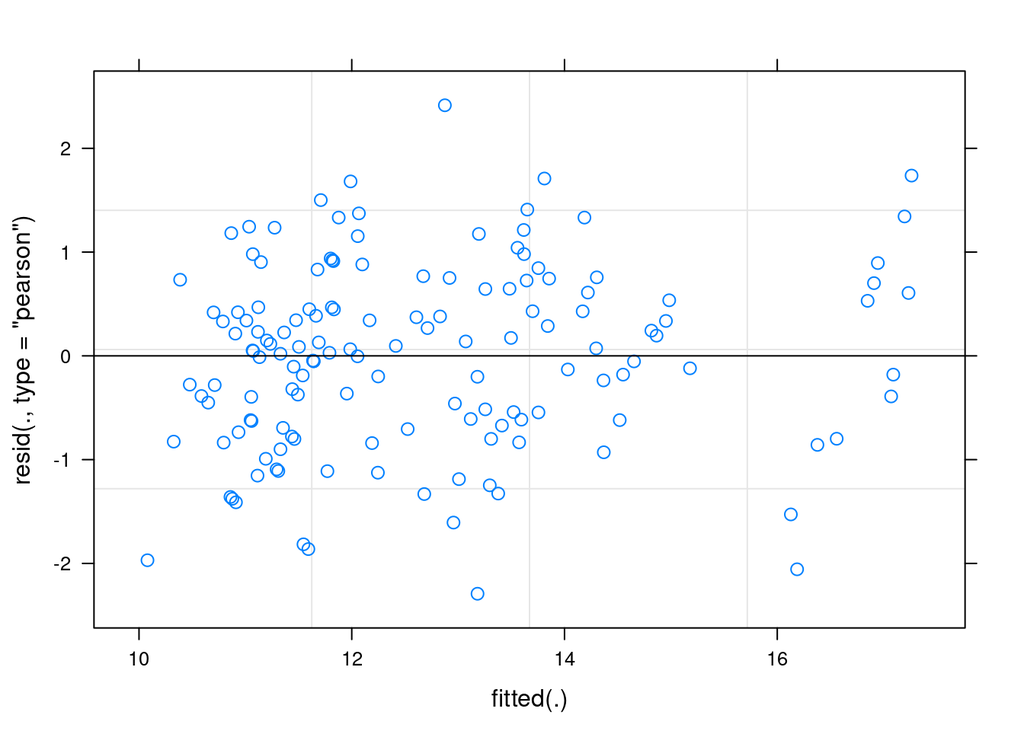

```r
plot(m1)
```

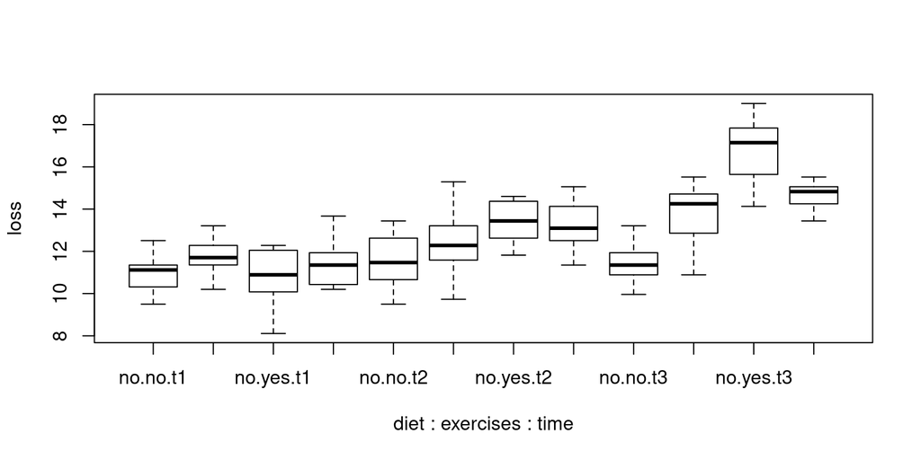

Figure 2.1: Gráfico de cajas de `loss` en cada grupo experimental.

```r
boxplot(loss ~ diet + exercises + time, weight.l)
```

Regresar al índice del curso